# Zombies Homework 3

#### Based on the two graphs above, it can be concluded that height originates from a normal distribution.

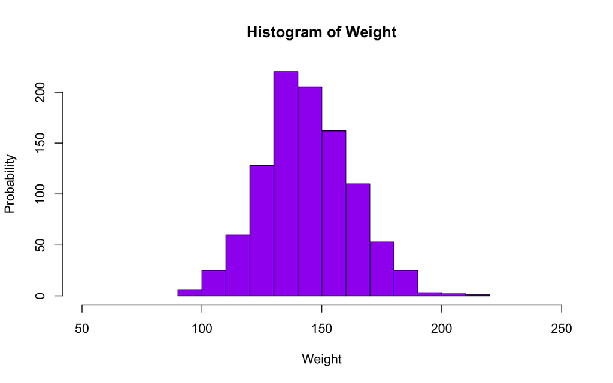

```r
hist(b, col = "purple", main = "Histogram of Weight", xlim = c(50,250), xlab = "Weight", ylab = "Probability")
```

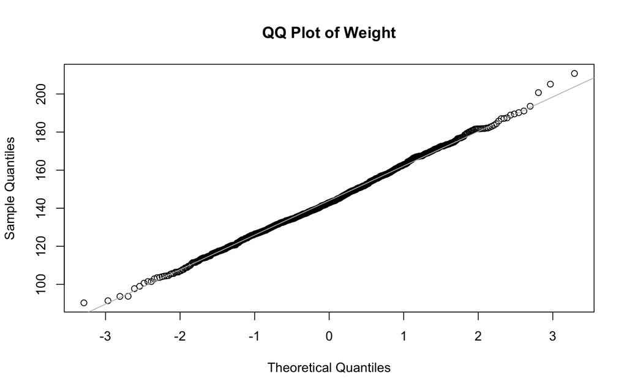

```r
qqnorm(b, main = "QQ Plot of Weight")
qqline(b,col="gray")
```

#### Based on the two graphs above, it can be concluded that weight originates from a normal distribution.

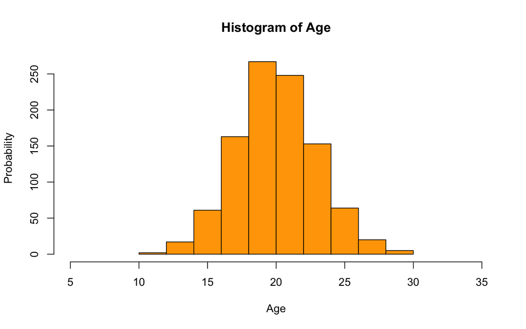

```r
hist(c, col = "orange", main = "Histogram of Age", xlim = c(5,35), xlab = "Age", ylab = "Probability")
```

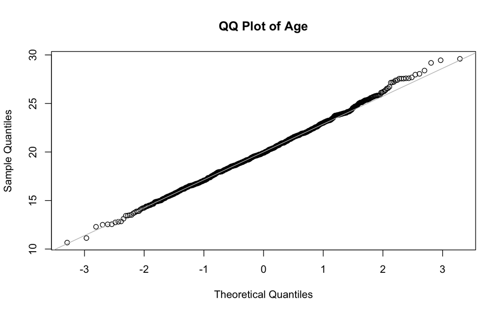

```r
qqnorm(c, main = "QQ Plot of Age" )
qqline(c,col="gray")
```

#### Based on the two graphs above, it can be concluded age originates from a normal distribution.

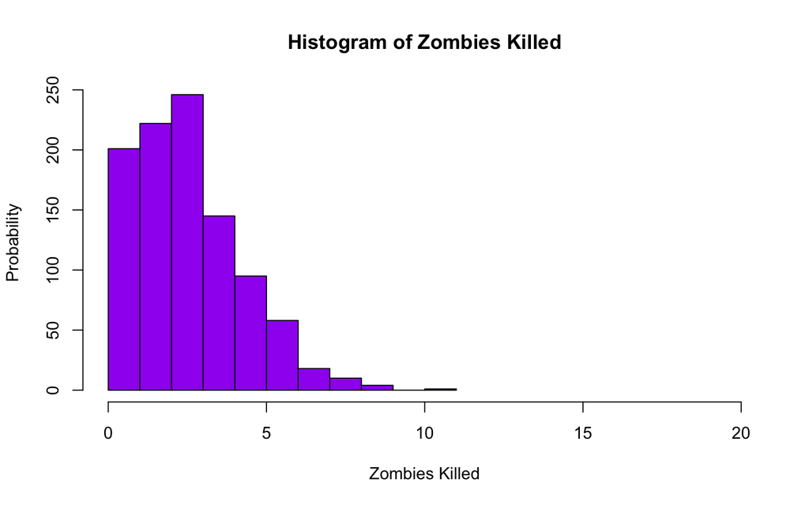

```r
hist(e, col = "purple", main = "Histogram of Zombies Killed", xlim = c(0,20), xlab = "Zombies Killed", ylab = "Probability")
```

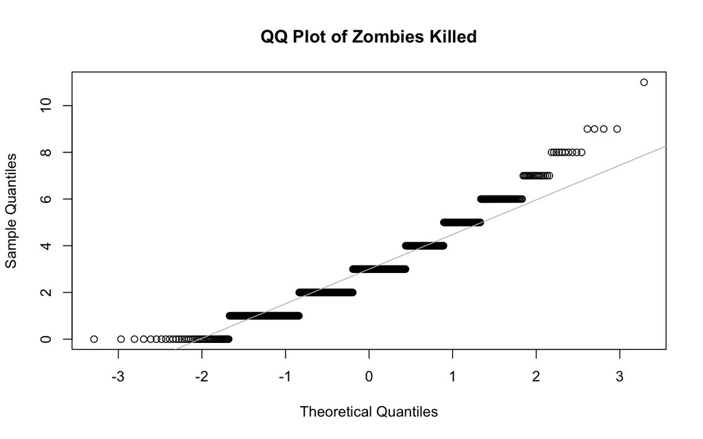

```r
qqnorm(e, main = "QQ Plot of Zombies Killed" )
qqline(e,col="gray")
```

#### Based on the two graphs above, it can be concluded that zombies killed does not originate from a normal distribution.

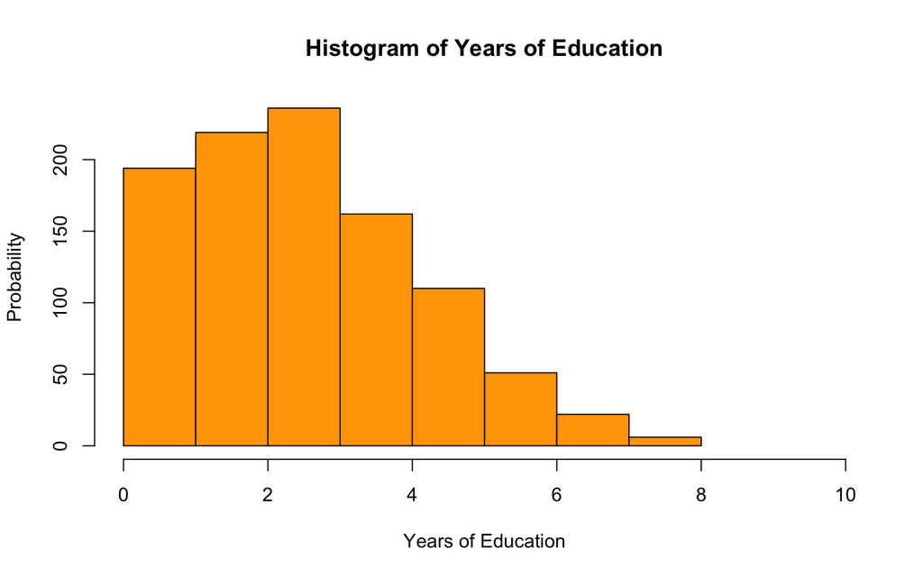

```r
hist(f, col = "orange", main = "Histogram of Years of Education", xlim = c(0,10), xlab = "Years of Education", ylab = "Probability")
```

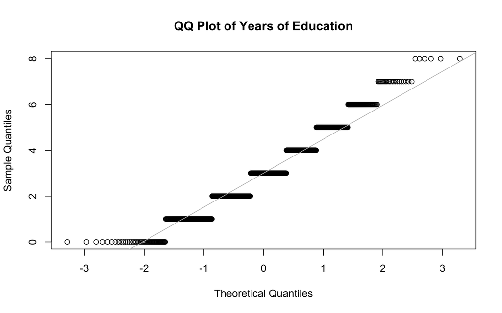

```r
qqnorm(f, main = "QQ Plot of Years of Education" )
qqline(f,col="gray")
```

#### Based on the two graphs above, it can be concluded that years of education does not originate from a normal distribution.

## Question 5

#### One Subset of 30 Zombies

```r
set.seed(1)
zombiesample <- sample_n(d, size = 30, replace = FALSE)
zombiesample
```

```
##     id  first_name last_name gender   height   weight zombies_killed
## 1  836       Susan   Hawkins Female 69.35963 133.1018              3
## 2  679    Benjamin      Ward   Male 61.95252 139.9611              2
## 3  129      Martin    Wagner   Male 70.26668 154.6746              2
## 4  930       Keith    Wagner   Male 63.24096 132.8480              3
## 5  509       Doris      Lane Female 62.33275 134.0491              3
## 6  471    Jennifer  Williams Female 62.29205 144.9394              2
## 7  299       Kelly     Burke Female 69.91124 145.7389              5
## 8  270 Christopher       Lee   Male 67.64806 130.5163              2
## 9  978      Willie  Richards   Male 64.73728 133.3641              5
## 10 187         Ann      Reid Female 71.02192 141.7984              2
## 11 307        Judy    Peters Female 63.76315 127.8650              4
## 12 597       Linda Patterson Female 63.14829 106.4643              2
## 13 277      Carlos Alexander   Male 75.21887 176.9457              3
## 14 874        Sean    Brooks   Male 68.52690 126.8207              1
```

[output cut: 47 more lines]

#### Means of the One Subset of 30 Zombies for Each Variable

```r
mh <- mean(zombiesample$height)
mh
```

```
## [1] 66.88522
```

```r
mw <- mean(zombiesample$weight)
mw
```

```
## [1] 142.2536
```

```r
ma <- mean(zombiesample$age)
ma
```

```
## [1] 19.68657
```

```r
mk <- mean(zombiesample$zombies_killed)
mk
```

```
## [1] 3.066667
```

```r
me <- mean(zombiesample$years_of_education)
me
```

```
## [1] 2.966667
```

#### Standard Deviations of the One Subset of 30 Zombies for Each Variable

```r
sd(zombiesample$height)
```

```
## [1] 3.735037
```

```r
sd(zombiesample$weight)
```

```
## [1] 16.22658
```

```r
sd(zombiesample$age)
```

```
## [1] 2.960476
```

```r
sd(zombiesample$zombies_killed)
```

```
## [1] 1.680175
```

```r
sd(zombiesample$years_of_education)
```

```
## [1] 1.691425
```

#### Standard Errors of the One Subset of 30 Zombies for Each Variable

```r
se(zombiesample$height)
```

```
## [1] 0.6819214
```

```r
se(zombiesample$weight)
```

```
## [1] 2.962555
```

```r
se(zombiesample$age)
```

```
## [1] 0.5405065
```

```r
se(zombiesample$zombies_killed)
```

```
## [1] 0.3067566
```

```r
se(zombiesample$years_of_education)
```

```
## [1] 0.3088106
```

#### CIs of 1 Subset of 30 Zombies Using a T-Test (I’m not sure if I can use the t.test here, but why not?)

```r
t.test(zombiesample$height)
```

```
##
##  One Sample t-test
##
## data:  zombiesample$height
## t = 98.083, df = 29, p-value < 2.2e-16
## alternative hypothesis: true mean is not equal to 0
## 95 percent confidence interval:
##  65.49053 68.27990
## sample estimates:
## mean of x
##  66.88522
```

```r
t.test(zombiesample$weight)
```

```
##
##  One Sample t-test
##
## data:  zombiesample$weight
## t = 48.017, df = 29, p-value < 2.2e-16
## alternative hypothesis: true mean is not equal to 0
## 95 percent confidence interval:
##  136.1945 148.3127
## sample estimates:
## mean of x
##  142.2536
```

```r
t.test(zombiesample$age)
```

```
##
##  One Sample t-test
##
## data:  zombiesample$age
## t = 36.422, df = 29, p-value < 2.2e-16
## alternative hypothesis: true mean is not equal to 0
## 95 percent confidence interval:
##  18.58111 20.79203
## sample estimates:
## mean of x
##  19.68657
```

```r
t.test(zombiesample$zombies_killed)
```

```
##
##  One Sample t-test
##
## data:  zombiesample$zombies_killed
## t = 9.9971, df = 29, p-value = 6.644e-11
## alternative hypothesis: true mean is not equal to 0
## 95 percent confidence interval:
##  2.439279 3.694054
## sample estimates:
## mean of x
##  3.066667
```

```r
t.test(zombiesample$years_of_education)
```

```
##
##  One Sample t-test
##
## data:  zombiesample$years_of_education
## t = 9.6068, df = 29, p-value = 1.627e-10
## alternative hypothesis: true mean is not equal to 0
## 95 percent confidence interval:
##  2.335078 3.598255
## sample estimates:
## mean of x
##  2.966667
```